# Predicting Success in March Madness from Regular Season Metrics

### by John Taormina, Jared Welsh, Will Snyder

## Goal: Use regular season statistics to predict success in March Madness.

### Purpose:

Why college basketball statistics? How much insight could you really get from a complex set of variables all influenced by the interactions of the human body, mental grit and agility, team politics and morale, and team experience? This a very valid question. One could say that you shouldn't even attempt to fully comprehend the seemingly quantum-mechanics-level complexity of these variables as they play out **between players**. Instead, you should attempt to distinguish between the influence of bigger picture metrics **at the team level**.

A logical starting point for determining the traits that make or break a team would be relating these traits to team success in March Madness. March Madness is a best of one tournament that moves at breakneck speed. The mental weight and intensity of March Madness implies the importance of one particular dynamic: **objective sense of a team's skill vs. its players' experience.** A skilled team that did well in the regular season has a reasonable chance of success in the playoffs. This is undoubtadly true, but the experience of that team implies cohesion and leadership: the most important traits for weathering the playoff storm.

### Structural Overview:

This tutorial consists of three parts: scraping, cleaning and organization, and analysis. It will walk you through the retrieval of 30 plus years of college basketball data from HTML tables to Pandas dataframes. You will organize this data in a logical manner and perform simple linear regression analysis to find key relationships. The data will be pulled from www.sports-reference.com. All compound metrics included in this database are **consistently defined**.

This tutorial does **not** present code **in exact execution order**. This tutorial presents each function in a logical ordering based on its **role in the data science life cycle**. For example, the scraping functions are defined in the scraping section. These scraping functions may be called from functions the organization section, or from other functions listed in the scraping section. Don't stress about the exact ordering of code; it is necessary for compliance with Python code structure and logical ordering in the data science life cycle.

Each function will be described in the context of it's role in the life cycle. If you wish to understand the inner programmatic structure of each function, they are commented extensively for that purpose. Important warnings related to OS compatibility and minor data inconsistencies are noted when relevant for each function.

#### Table of Contents:

1. Scraping
2. Organization

#### Libraries you will need (all available through pip/Anaconda):

1. Pandas
2. Beautfiul Soup and requests
3. math and Numpy
4. os and sys
5. Matplotlib and seaborn
6. google

```python
import sys
!{sys.executable} -m pip install lxml

from bs4 import BeautifulSoup
import matplotlib.pyplot as plt
import requests
import pandas as pd
import re
from math import floor, ceil
import numpy as np
import seaborn as sns
import statsmodels.formula.api as smf
from collections import Counter
from matplotlib.lines import Line2D
from googlesearch import search
import pathlib
import os.path
from os import path


# These are all settings to make running easier
pd.set_option("display.max_rows", None)
pd.set_option("display.max_columns", None)
# sns.set(style="whitegrid")
```

```python
# This function is used to store expected value, slope and the data name
# This is useful for residual analysis so that expected values do not need to be re-calculated
def update_p_reg(p_reg, name, slope, intercept, ev):
    p_reg[name] = {}
    p_reg[name]['slope'] = slope
    p_reg[name]['intercept'] = intercept
    p_reg[name]['ev'] = ev
```

```python
# This function is used to create the legend. This creates an element that links year to the color used for that year
# on the scatterplot. From there it is added to the legend to increase clarity.
def line(label):
    return Line2D([0], [0],  color=label[1], label=str(label[0]))
```

```python
# This dictionary and function are used to standardize names across the different pages.
# One of the issues that we ran into was that some colleges had different names for their tournament results compared
# to their yearly rating. Because of this when we tried to merge the tournament wins and ratings dataframe
# there was no match for these schools as we merged on school name and year. This dictionary replaces the tournament
# name with the ratings name in order to ensure the dataframes can be merged correctly.
new_name = {
    'UNC': 'North Carolina', 'NC State': 'North Carolina State', 'USC': 'Southern California',
    'ETSU': 'East Tennessee State', 'VCU': 'Virginia Commonwealth', 'LSU': 'Louisiana State', 'UConn': 'Connecticut',
    'BYU': 'Brigham Young', 'Pitt': 'Pittsburgh', 'UNLV': 'Nevada-Las Vegas', 'UMBC': 'Boston College',
    'St. Joseph\'s': 'Saint Joseph\'s', 'California': 'University of California', 'UCSB': 'UC-Santa Barbara',
    'UTEP': 'Texas-El Paso', 'UTSA': 'Texas-San Antonio', 'LIU-Brooklyn': 'Long Island University',
    'St. Peter\'s': 'Saint Peter\'s', 'Saint Mary\'s': 'Saint Mary\'s (CA)',
    'UNC Asheville': 'North Carolina-Asheville', 'Penn': 'Pennsylvania', 'TCU': 'Texas Christian',
    'UNC Greensboro': 'North Carolina-Greensboro', 'UNC Wilmington': 'North Carolina-Wilmington',
    'Ole Miss': 'Mississippi', 'SMU': 'Southern Methodist', 'UMass': 'Massachusetts',
    'Southern Miss': 'Southern Mississippi', 'Detroit': 'Detroit Mercy'
}

def fix_name(tag):
    return new_name[tag.text] if tag.text in new_name.keys() else tag.text
```

# Scraping and Cleaning Functions

This tutorial requires college basketball data from 1988 to 2019. An excellent source for this can be found at www.sports-reference.com. We will iterate through their database year by year, team by team and convert the html tables into Pandas Dataframes.

1. Part A
2. Part B
3. Part C

### A few caveats:

1. Team names are abbreviated in some tables. The 'abbreviation_map' dictionary and 'fix_name' function below solve that issue.
2. Sending too many requests to a URL will trigger google's real-user authentication block. By using the googlesearch library, we can search for each page and find the correct result (by testing for presence of known DOM elements) without being blocked.

```python
abbreviation_map = {
    'UNC': 'North Carolina', 'NC State': 'North Carolina State', 'USC': 'Southern California',
    'ETSU': 'East Tennessee State', 'VCU': 'Virginia Commonwealth', 'LSU': 'Louisiana State', 'UConn': 'Connecticut',
    'BYU': 'Brigham Young', 'Pitt': 'Pittsburgh', 'UNLV': 'Nevada-Las Vegas', 'UMBC': 'Boston College',
    'St. Joseph\'s': 'Saint Joseph\'s', 'California': 'University of California', 'UCSB': 'UC-Santa Barbara',
    'UTEP': 'Texas-El Paso', 'UTSA': 'Texas-San Antonio', 'LIU-Brooklyn': 'Long Island University',
    'St. Peter\'s': 'Saint Peter\'s', 'Saint Mary\'s': 'Saint Mary\'s (CA)',
    'UNC Asheville': 'North Carolina-Asheville', 'Penn': 'Pennsylvania', 'TCU': 'Texas Christian',
    'UNC Greensboro': 'North Carolina-Greensboro', 'UNC Wilmington': 'North Carolina-Wilmington',
    'Ole Miss': 'Mississippi', 'SMU': 'Southern Methodist', 'UMass': 'Massachusetts',
    'Southern Miss': 'Southern Mississippi', 'Detroit': 'Detroit Mercy'
}

def fix_name(tag):
    return abbreviation_map[tag.text] if tag.text in abbreviation_map.keys() else tag.text
```

### Part A: Scraping Roster Data per Team per Year

This function saves roster files for each team for each year in CSV files. If you don't already have the CSV files, this will take a while.

```python
# This function downloads the roster csv files according to each year and saves them
# in a local directory for easier access and manipulation
# We believed this was necessary because requesting the rosters each time
# we wanted to rerun the program took too long, so saving them was much easier
# It works by "guessing" each teams roster url with /cbb/schools/TEAMNAME/YEAR
# If this does not result in a successful lookup of a page, then it makes a google search
# and uses regex to find the correct link
def generate_all_roster_csv(year):
    tourney_wins = get_tourney_wins(year)
    playoff_teams = tourney_wins.keys()
    count = 0
    for team in playoff_teams:
        count = count + 1
        if(not not(path.exists('rosters' + '/' + str(year) + '/' + team + '.csv'))):
            pass
        else:
            team_rep = team.replace(' ','-')
            team_rep = team_rep.lower()
            find_url = 'https://www.sports-reference.com/cbb/schools/'+team_rep+'/2019.html'
            req = requests.get(find_url)

            if(req.status_code == 404):
                search_term = team + ' ' + str(year) + ' site:https://www.sports-reference.com/cbb/'
                team_url = ''
                for url in search(search_term, num=5, pause=4.0, user_agent='your mom'):
                    team_url = url
                    if(re.match(r"^https:\/\/www\.sports-reference\.com\/cbb\/[\w+(?:\-\w+)+\/]*"+str(year)+"\.html$", team_url)):
                        break
                req = requests.get(team_url)
                soup = BeautifulSoup(re.sub("<!--|-->", "", req.text), 'html.parser')
                table = soup.findAll('table', id="roster")[0]
                roster_df = pd.read_html(str(table))
                pathlib.Path('rosters' + '\\' + str(year)).mkdir(parents=True, exist_ok=True)
                save_path = 'rosters' + '\\' + str(year) + '\\' + team + '.csv'
                roster_df[0].to_csv(save_path)
            else:
                soup = BeautifulSoup(re.sub("<!--|-->", "", req.text), 'html.parser')
                table = soup.findAll('table', id="roster")[0]
                roster_df = pd.read_html(str(table))
                pathlib.Path('rosters' + '\\' + str(year)).mkdir(parents=True, exist_ok=True)
                save_path = 'rosters' + '\\' + str(year) + '\\' + team + '.csv'
                roster_df[0].to_csv(save_path)

    print('Finished data for year: ', year)
```

### Part B: Scraping Tournament Data per Year per Team

Next we must iterate through each year and team to get records of each tournament (March Madness). We then return a dictionary linking teams to their tournament wins for each year (a Pandas column).

```python
# get_tourney_wins is a function that is used to calculate the number of tournament wins a team has.
# It accepts a year which is used to create the url. The website shows the tournament as a bracket.
# Due to the ways that brackets work, you tell how many times a team has won by how many times their
# name shows up. For example, a team that only shows up once, won no games as they were eliminated in
# the first round. A team that shows up twice, won 1 game as they were eliminated in the second round.
# Using this method we calculate the number of tournament wins by adding every name that appears to a list.
# We then use the Counter function, which returns a dictionary where the key is the string in the list,
# and the value is the number of times it appears. Using this we are able to count the number of tournament
# wins without having to count the names ourselves.

# The function first creates an empty list that will hold the names that appear in the bracket.
# Next, we get the url and remove comments. When then find the div item that houses the bracket. From there
# we look at the children of the div, skipping every other element because they aren't the brackets.
# There are two different types of brackets, conference brackets and the final four. Because the final four
# bracket has a different id, we need to account for that in the first line. From there we continue into the
# html until we find the element that houses the team names. From there we get all of the team names and replace
# them with their ratings counterpart, to ensure name standardization. finally we return the counter representation
# of our list, giving us a dictionary with team names and their tourney wins.

def get_tourney_wins(year):
    playoff_teams = []

    url = 'https://www.sports-reference.com/cbb/postseason/'+str(year)+'-ncaa.html'
    req = requests.get(url)
    soup = BeautifulSoup(re.sub("<!--|-->", "", req.text), 'html.parser')

    b = soup.find('div', {'id' : 'brackets'})

    for conf in list(b.children)[1::2]:
        cls = 'team4' if 'national' in conf.get('id') else 'team16'
        bracket = conf.find('div', {'class': cls})
        rnds = bracket.findAll('div', {'class': 'round'})
        for rnd in rnds:
            divlist = filter(lambda a: 'schools' in a['href'], rnd.findAll('a'))
            playoff_teams += [fix_name(a) for a in divlist]


    return dict(Counter(playoff_teams))
```

### Part C: Scraping Performance Data per Year per Team

```python
# This function accepts a year, which is used in creating the url for the data we are trying to access.
# In this function we first call the get_tourney_wins function.
# This function is called first because we only care about teams that made it to the tournament.
# The ratings page has all teams that competed that year. In order to save time we remove all teams
# that did not make the playoffs.

# Next, we use requests to get the html page containing the ratings for each year. We remove the comments
# from the document to make parsing easier. We then get the table tag, which has all the schools ratings.
# We create a dataframe from the table. Every 20 entries on the website, a new table is used/
# Due to the way that the data is laid out on the website, multiple dataframes are actually created
# when calling read_html. In order to combine these dataframes, we use concat. We also need to droplevel
# to fix the column names. If we do not use this, the column names are set as the first row of data.

# Now that the dataframe is beginning to take shape, we remove all columns that aren't needed. From there,
# we remove all rows that do not contain data. Because of the way the table is laid out on the website,
# the column names appear multiple times as data. We remove this and reset the index.
# From there we add new columns used for managing the year, flags to drop non-playoff teams and additionally
# prep column filled out later.

# From there we change the column type to a numerical value for later use and update the tournament wins for
# each team. We then drop all non-tournament teams using the column we created and then remove that column.
def generate_df(year):
    tourney_wins = get_tourney_wins(year)
    playoff_teams = tourney_wins.keys()

    req = requests.get('https://www.sports-reference.com/cbb/seasons/'+str(year)+'-ratings.html')
    soup = BeautifulSoup(re.sub("<!--|-->", "", req.text), 'html.parser')
    table = soup.findAll('table')
    s_df = pd.read_html(str(table))

    temp_df = (pd.concat(s_df))
    temp_df.columns = temp_df.columns.droplevel()
    temp_df.reset_index(drop=True, inplace=True)

    standings_df = temp_df[['School', 'SRS', 'SOS', 'OSRS', 'DSRS']].copy()
    standings_df = standings_df[~standings_df.SRS.str.contains("SRS")]
    standings_df.dropna(inplace=True)

    standings_df['EXP'] = 0.0
    standings_df['year'] = year
    standings_df['playoff'] = False
    standings_df['t_wins'] = 0

    standings_df.SRS = standings_df.SRS.astype(float)
    standings_df.OSRS = standings_df.OSRS.astype(float)
    standings_df.DSRS = standings_df.DSRS.astype(float)
    standings_df.SOS = standings_df.SOS.astype(float)

    for indx, row in standings_df.iterrows():
        if row['School'] in playoff_teams:
            wins = tourney_wins[row['School']]
            standings_df.loc[indx, 'playoff'] = True
            standings_df.loc[indx, 't_wins'] =  wins - 1 if wins < 5 else wins - 2

    standings_df = standings_df[standings_df.playoff].reset_index(drop=True)
    del standings_df['playoff']
    return standings_df
```

# Organization and Preprocessing

Before we begin fitting our linear regression model to our data, we need to get all of our data in one place and refine our metrics a little.

### Part A: Migrating Team Roster Data from CSV to Pandas

Now that we've got our roster data in CSV files, we need to store it in a Pandas dataframe. Once we've done this, for each team for each year, we can calculate total player experience.

Total player experience is a crucial metric. Players are by default ranked by their row ordering in the scraped tables. The player experience metric multplies this rank by a weight corresponding to the player's year. The wieghts for freshmen through seniors are 1.0 to 1.6 respectively.

If the best players on a team are all seniors, the player experience metric is maximized, since you have skilled players with leadership capabilities and knowledge. If a team's best players are mostly freshmen who have not faced the pressure of playoffs, the experience metric will reflect that.

**IMPORTANT NOTE:** When calling this function, make sure you use the appropriate path delimiters for your operating system. '/' (MAC-OS) is the delimiter used by default; if you are using Windows, replace them with '\\'.

```python
# This fuction calculates a player experience variable that
# takes into account the skill of a player, and how old they are (FR, SO, JR, SR)
def calculate_player_experience(year, team):
    df_path = 'rosters' + '/' + str(year) + '/' + team + '.csv'
    df = pd.read_csv(df_path)
    # Weights based on each starter, then bench as a whole player
    start_weight = 10
    class_weights = {'FR': 1, 'SO': 1.2, 'JR': 1.4, 'SR': 1.6}
    player_exp = 0
    df = df.fillna('X')
    for index, row in df.iterrows():
        if(row['Class'] != 'X'):
            player_exp = player_exp + class_weights[row['Class']]*start_weight
            start_weight = start_weight - 1
            player_exp = round(player_exp, 2)

            return(player_exp)
```

Now that we have a function to calculate a team's total metric experience for a particular year, we build a dataframe holding that data for every team per year.

```python
# This function works very similarly to generate_df... except it creates columns for
# tournament experience and roster experience instead

def generate_exp_df(year):
    tourney_wins = get_tourney_wins(year)
    playoff_teams = tourney_wins.keys()
    School = []
    year_arr = []
    player_exp = []
    tourn_exp = []
    for team in playoff_teams:
        School.append(team)
        year_arr.append(year)
        player_exp.append(calculate_player_experience(year, team))
        #tourn_exp.append(calculate_prev_tournament_wins(year, team))
    experience_df = pd.DataFrame.from_dict({'School':School, 'year': year_arr, 'player_exp': player_exp})
    return(experience_df)
```

### Part B: Putting the Team Experience and Team Performance Dataframes Together

Once we have these dataframes merged, we can begin our analysis.

```python
# This code calls the functions used to create the performance and experience dataframes and then adds
# them all to a list for each year. After that it combines all the dataframes together and resets the
# index. It saves the year range to be used later to create the legend and the new means dataframe.

df_list = []

print("\nGenerating Performance Dataframes...\n")

for i in range(1988, 2019):
    a = ', ' if i != 2019 else '.'
    print('{}{}'.format(i, a), end='')
    df_list.append((generate_df(i)))


df = pd.concat(df_list)
df.reset_index(drop=True, inplace=True)

df = df[['School', 'year', 't_wins', 'SOS', 'EXP', 'SRS', 'OSRS', 'DSRS']]




exp_list_df = []

print("\n\nGenerating Experience Dataframes...\n")

for i in range(1988, 2019):
    a = ', ' if i != 2019 else '.'
    print('{}{}'.format(i, a), end='')
    exp_list_df.append((generate_exp_df(i)))

exp_df = pd.concat(exp_list_df)
exp_df.reset_index(drop=True, inplace=True)




print("\n\nJoining Performance and Experience Dataframes\n")

joined_df = pd.merge(df, exp_df, how='left', on=['School','year'])
```

```
Generating Performance Dataframes...

1988, 1989, 1990, 1991, 1992, 1993, 1994, 1995, 1996, 1997, 1998, 1999, 2000, 2001, 2002, 2003, 2004, 2005, 2006, 2007, 2008, 2009, 2010, 2011, 2012, 2013, 2014, 2015, 2016, 2017, 2018,

Generating Experience Dataframes...

1988, 1989, 1990, 1991, 1992, 1993, 1994, 1995, 1996, 1997, 1998, 1999, 2000, 2001, 2002, 2003, 2004, 2005, 2006, 2007, 2008, 2009, 2010, 2011, 2012, 2013, 2014, 2015, 2016, 2017, 2018,
Joining Performance and Experience Dataframes
```

### Part C: Preprocessing

Now that we have everything in one dataframe, we need to refine our player experience and team performance metrics to work well with linear regression.

First, for each player, we multiply their weighted experience score by their teams SRS. We do this to account for the interaction between player skill and team performance (ie, the best players on the best teams should be further weighted).

```python
# Calculate better player experience
for index, row in joined_df.iterrows():
    joined_df.loc[index, "player_exp"] = (row['player_exp'] * (row['SRS']))/100
```

```python
year_range = range(1988,2019)

df_means = pd.DataFrame()
df_means['year'] = [a for _ in range(7) for a in year_range]
df_means['t_wins'] = [a for a in range(7) for _ in year_range]
cols = ['SOS', 'SRS', 'OSRS', 'DSRS', 'player_exp']

for i in cols:
    df_means[i] = joined_df.groupby(['t_wins', 'year'])[i].mean().tolist()
```

# Regression Analysis

We're finally ready to start hunting for relationships in our hard earned data. We'll run linear regression for each individual metric and observe their respective correlations to playoff success. Each regression will consist of an intercept and a weight for a single metric and will be plotted as immediately after generation.

This tutorial does not attempt more complicated regression models involving interaction parameters and polynomial parameter configurations.

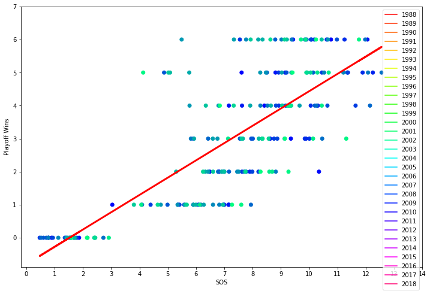

```
                            OLS Regression Results
==============================================================================
Dep. Variable:                 t_wins   R-squared:                       0.607
Model:                            OLS   Adj. R-squared:                  0.605
Method:                 Least Squares   F-statistic:                     331.5
Date:                Fri, 19 Jul 2019   Prob (F-statistic):           1.95e-45
Time:                        11:25:56   Log-Likelihood:                -357.10
No. Observations:                 217   AIC:                             718.2
Df Residuals:                     215   BIC:                             725.0
Df Model:                           1
Covariance Type:            nonrobust
==============================================================================
                 coef    std err          t      P>|t|      [0.025      0.975]
------------------------------------------------------------------------------
Intercept     -0.7973      0.225     -3.537      0.000      -1.242      -0.353
SOS            0.5233      0.029     18.207      0.000       0.467       0.580
==============================================================================
Omnibus:                       13.882   Durbin-Watson:                   0.599
Prob(Omnibus):                  0.001   Jarque-Bera (JB):               14.841
Skew:                           0.633   Prob(JB):                     0.000599
Kurtosis:                       3.199   Cond. No.                         21.0
==============================================================================

Warnings:
[1] Standard Errors assume that the covariance matrix of the errors is correctly specified.
```

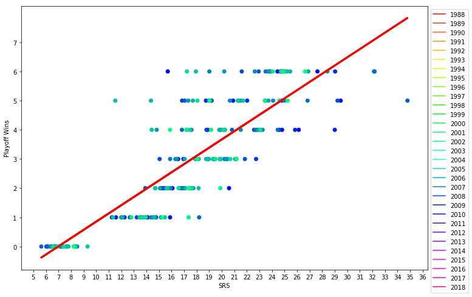

```
                            OLS Regression Results
==============================================================================
Dep. Variable:                 t_wins   R-squared:                       0.718
Model:                            OLS   Adj. R-squared:                  0.716
Method:                 Least Squares   F-statistic:                     546.2
Date:                Fri, 19 Jul 2019   Prob (F-statistic):           6.09e-61
Time:                        11:25:57   Log-Likelihood:                -321.15
No. Observations:                 217   AIC:                             646.3
Df Residuals:                     215   BIC:                             653.1
Df Model:                           1
Covariance Type:            nonrobust
==============================================================================
                 coef    std err          t      P>|t|      [0.025      0.975]
------------------------------------------------------------------------------
Intercept     -1.9636      0.224     -8.750      0.000      -2.406      -1.521
SRS            0.2816      0.012     23.370      0.000       0.258       0.305
==============================================================================
Omnibus:                       24.788   Durbin-Watson:                   1.160
Prob(Omnibus):                  0.000   Jarque-Bera (JB):               30.634
Skew:                           0.793   Prob(JB):                     2.23e-07
Kurtosis:                       3.933   Cond. No.                         57.8
==============================================================================

Warnings:
[1] Standard Errors assume that the covariance matrix of the errors is correctly specified.
```

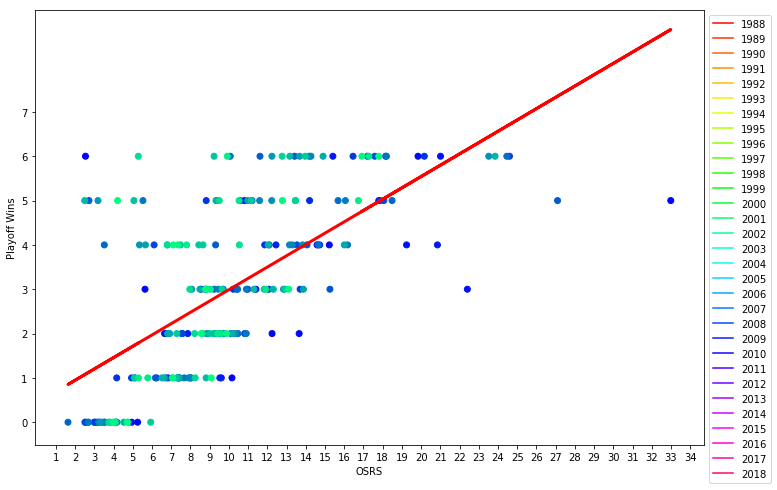

```
                            OLS Regression Results
==============================================================================
Dep. Variable:                 t_wins   R-squared:                       0.439
Model:                            OLS   Adj. R-squared:                  0.436
Method:                 Least Squares   F-statistic:                     168.2
Date:                Fri, 19 Jul 2019   Prob (F-statistic):           8.42e-29
Time:                        11:25:57   Log-Likelihood:                -395.61
No. Observations:                 217   AIC:                             795.2
Df Residuals:                     215   BIC:                             802.0
Df Model:                           1
Covariance Type:            nonrobust
==============================================================================
                 coef    std err          t      P>|t|      [0.025      0.975]
------------------------------------------------------------------------------
Intercept      0.4364      0.222      1.961      0.051      -0.002       0.875
OSRS           0.2553      0.020     12.971      0.000       0.216       0.294
==============================================================================
Omnibus:                       18.007   Durbin-Watson:                   0.801
Prob(Omnibus):                  0.000   Jarque-Bera (JB):               20.369
Skew:                           0.747   Prob(JB):                     3.78e-05
Kurtosis:                       3.154   Cond. No.                         24.8
==============================================================================

Warnings:
[1] Standard Errors assume that the covariance matrix of the errors is correctly specified.
```

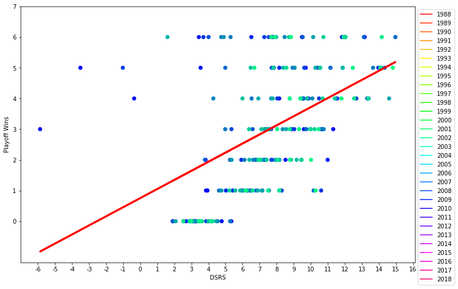

```
                            OLS Regression Results
==============================================================================
Dep. Variable:                 t_wins   R-squared:                       0.245
Model:                            OLS   Adj. R-squared:                  0.242
Method:                 Least Squares   F-statistic:                     69.93
Date:                Fri, 19 Jul 2019   Prob (F-statistic):           7.71e-15
Time:                        11:25:58   Log-Likelihood:                -427.77
No. Observations:                 217   AIC:                             859.5
Df Residuals:                     215   BIC:                             866.3
Df Model:                           1
Covariance Type:            nonrobust
==============================================================================
                 coef    std err          t      P>|t|      [0.025      0.975]
------------------------------------------------------------------------------
Intercept      0.7531      0.294      2.565      0.011       0.174       1.332
DSRS           0.2962      0.035      8.362      0.000       0.226       0.366
==============================================================================
Omnibus:                       19.443   Durbin-Watson:                   0.451
Prob(Omnibus):                  0.000   Jarque-Bera (JB):               22.875
Skew:                           0.794   Prob(JB):                     1.08e-05
Kurtosis:                       2.925   Cond. No.                         20.8
==============================================================================

Warnings:
[1] Standard Errors assume that the covariance matrix of the errors is correctly specified.
```

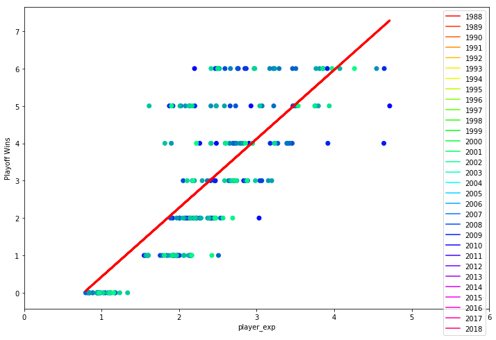

```
                            OLS Regression Results
==============================================================================
Dep. Variable:                 t_wins   R-squared:                       0.597
Model:                            OLS   Adj. R-squared:                  0.595
Method:                 Least Squares   F-statistic:                     317.8
Date:                Fri, 19 Jul 2019   Prob (F-statistic):           2.97e-44
Time:                        11:25:58   Log-Likelihood:                -359.85
No. Observations:                 217   AIC:                             723.7
Df Residuals:                     215   BIC:                             730.5
Df Model:                           1
Covariance Type:            nonrobust
==============================================================================
                 coef    std err          t      P>|t|      [0.025      0.975]
------------------------------------------------------------------------------
Intercept     -1.4174      0.262     -5.400      0.000      -1.935      -0.900
player_exp     1.8450      0.103     17.828      0.000       1.641       2.049
==============================================================================
Omnibus:                       23.940   Durbin-Watson:                   0.802
Prob(Omnibus):                  0.000   Jarque-Bera (JB):               28.895
Skew:                           0.888   Prob(JB):                     5.31e-07
Kurtosis:                       3.202   Cond. No.                         8.76
==============================================================================

Warnings:
[1] Standard Errors assume that the covariance matrix of the errors is correctly specified.
```

```python
# First we create our dataframe and fill out the years and tourney wins. We then generate the color values for the
# legend and create our dictionary to store expected values, slope and other important information for each year.
# We loop through each column and perform linear regression with that column alone. From there we calculate the
# expected values using the slope and coefficient and then graph the line and values using matplotlib. We create
# the legend and format the colors, size, and labels of the graph.

# We also add the value to the dictionary for later analysis.


results_dict = {}

leg = [line(label) for label in zip(year_range, plt.cm.hsv(range(0, 255, int(255/len(year_range)))))]
p_reg = {}

for i in cols:
    #df_means[i] = joined_df.groupby(['t_wins', 'year'])[i].mean().tolist()

    result = smf.ols(formula='t_wins ~ {}'.format(i), data=df_means).fit()

    m = result.params[i]
    b = result.params['Intercept']

    xt = range(floor(df_means[i].min()), ceil(df_means[i].max() + 2))
    x = df_means[i].tolist()
    y = [m * a + b for a in x[1:-1]]

    fig, ax = plt.subplots()
    fig.set_size_inches(12, 8)
    ax.plot(x[1:-1], y, color='red', linewidth=3.0)
    ax.scatter(df_means[i], df_means['t_wins'], c=df_means['year'], cmap=plt.cm.get_cmap('winter'))
    ax.legend(handles=leg, bbox_to_anchor=(1, 1))

    plt.xlabel(i)
    plt.ylabel('Playoff Wins')
    plt.xticks(xt, xt)
    plt.yticks(range(8), range(8))

    plt.show()

    print(result.summary())
    update_p_reg(p_reg, i, m, b, y)

    results_dict[i] = result
```

# Model Evaluation

Here we evaluate our linear regression model generated in the previous section.

We test it on data from 2019. Evaluating our models on new data is a very simple process. We reuse our methods for generating data from 1988-2018 to generate a dataframe with only 2019 data. We'll need to weight the player experience we saved in the CSV file with the each team's SRS for that year, since that step is not performed in the CSV generation step.

```python
latest_year = pd.merge(generate_df(2019), generate_exp_df(2019), how='left', on=['School','year'])

# Calculate better player experience
for index, row in latest_year.iterrows():
    latest_year.loc[index, "player_exp"] = (row['player_exp'] * (row['SRS']))/100

latest_data = latest_year[['SRS', 'SOS', 'OSRS', 'DSRS', 'player_exp']]
```

Then for each feature we will use its corresponding model to predict the tournament wins for 2019 and compare the correlations.

```python
# Our model won't output whole numbers, so we round each one of them down. Sometimes our model
# will output negative numbers, we simply convert those to 0s.
def round_results(d):
    for k, v in d.iteritems():
        d[k] = round(v-1)
        if d[k] < 0: d[k] = 0


#For each feature, make a prediction for 2019 and print the correlation.
for i in cols:

    predicted = results_dict[i].predict(latest_data)
    round_results(predicted)
    latest_year['predicted'] = predicted
    latest_year[['School', 't_wins', 'predicted']]

    predicted_res = latest_year.sort_values(by=['predicted'], ascending=False)

    print("Correlation for " + i + ": " + str(predicted_res['t_wins'].corr(predicted_res['predicted'])))
```

```
Correlation for SOS: 0.5296339265170005
Correlation for SRS: 0.7745949929534893
Correlation for OSRS: 0.5102406173302974
Correlation for DSRS: 0.536098761896051
Correlation for player_exp: 0.7113264992061462
```

# Conclusion

Our model is rather accurate; it certinaly won't spit out a winning bracket, but for a basic application of linear regression it is impressive.

```python
# # Run this if you need to generate local CSV files for rosters
# # Generate Roster CSVs
# roster_team_links = {}
# for year in range(1988,2020):
#     generate_all_roster_csv(year)
```